# 2017-01-08 part 1 Linear Regression

```python
from datetime import datetime

print('Last run: {}'.format(datetime.now()))
```

```
Last run: 2017-01-08 19:13:30.276000
```

```python
from IPython.display import HTML

HTML('''<script>
code_show=true;
function code_toggle() {
 if (code_show){
 $('div.input').hide();
 } else {
 $('div.input').show();
 }
 code_show = !code_show
}
$( document ).ready(code_toggle);
</script>
<form action="javascript:code_toggle()"><input type="submit" value="Click here to toggle on/off the raw code."></form>''')
```

This is part 1 of 8 series of execises based on the famous course on Machine Learning taught by Prof. [Andrew Ng](https://en.wikipedia.org/wiki/Andrew_Ng) at Stanford U. The course is available at [Coursera](https://www.coursera.org/learn/machine-learning).

# Table of Contents

```python
%%javascript
$.getScript('https://kmahelona.github.io/ipython_notebook_goodies/ipython_notebook_toc.js')
```

```python
#import libraries
%matplotlib inline
import matplotlib.pyplot as plt
import numpy as np
```

# 1. Linear regression with one variable

## Introduction

In this part of this exercise, we will implement linear regression with one variable to predict profits for a food truck. Suppose you are the CEO of a restaurant franchise and are considering different cities for opening a new outlet. The chain already has trucks in various cities and you have data for profits and populations from the cities.

You would like to use this data to help you select which city to expand to next. The file `ex1data1.txt` contains the dataset for our linear regression problem. The first column is the **population of a city** and the second column is the **profit** of a food truck in that city. A negative value for profit indicates a loss.

```python
datafile = 'data/ex1data1.txt'
cols = np.loadtxt(datafile,delimiter=',',usecols=(0,1),unpack=True) #Read in comma separated data
```

```python
#show first 5 elements
cols[0,:5] #1st col: population
```

```
array([ 6.1101,  5.5277,  8.5186,  7.0032,  5.8598])
```

```python
cols[0,:5] #2nd col: profit
```

[output not shown]

```python
cols.shape #num of row,col
```

```
(2L, 97L)
```

```python
#Form the usual "X" matrix and "y" vector
X = np.transpose(np.array(cols[:-1]))
y = np.transpose(np.array(cols[-1:]))
m = y.size # number of training examples

#Insert the usual column of 1's into the "X" matrix
X = np.insert(X,0,1,axis=1)
```

```python
X[:5]
```

```
array([[ 1.    ,  6.1101],
       [ 1.    ,  5.5277],
       [ 1.    ,  8.5186],
       [ 1.    ,  7.0032],
       [ 1.    ,  5.8598]])
```

```python
y[:5]
```

```
array([[ 17.592 ],
       [  9.1302],
       [ 13.662 ],
       [ 11.854 ],
       [  6.8233]])
```

## 2.1 Plotting the Data

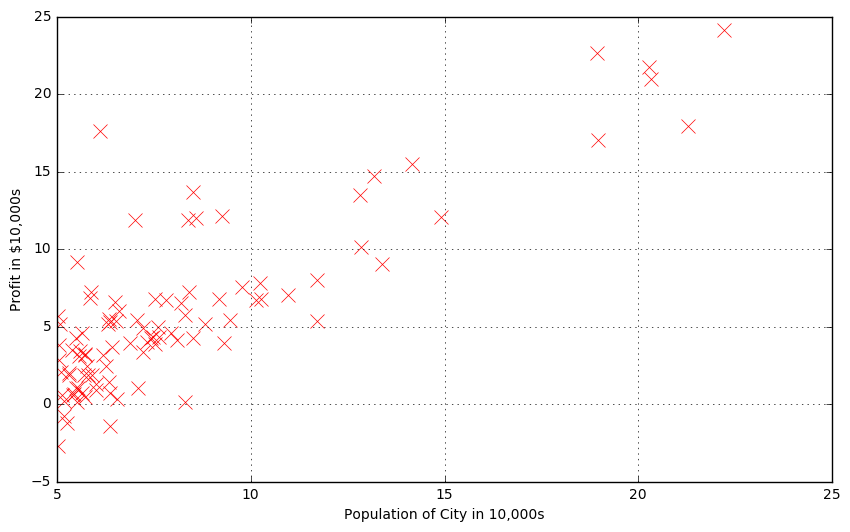

```python
#Plot the data to see what it looks like
plt.figure(figsize=(10,6))
plt.plot(X[:,1],y[:,0],'rx',markersize=10)
plt.grid(True) #Always plot.grid true!

#add labels
plt.ylabel('Profit in $10,000s')
plt.xlabel('Population of City in 10,000s')
```

## 2.2 Gradient Descent

The objective of linear regression is to minimize the cost function $$ J(\theta)=\frac{1}{2m}\sum\limits_{i=1}^m {(h_{\theta}(x^{(i)}) - y^{(i)})^2 } $$ where the hypothesis $h_{\theta}(x)$ is given by the linear model $$ h_{\theta}(x) = \theta^T x = \theta_0 + \theta_1x_1 $$

Here $T$ refers to matrix transpose operation. Recall that the parameters of our model are the $\theta_j$ values. These are the values we will adjust to minimize cost $J(\theta)$. One way to do this is to use the batch gradient descent algorithm. In batch gradient descent, each iteration performs the update $$ \theta_j := \theta_j - \alpha \frac{1}{m}\sum\limits_{i=1}^m {(h_{\theta}(x^{(i)}) - y^{(i)}) }x^{(i)}_j $$ simultaneously update $\theta_j$ for all $j$. With each step of gradient descent, our parameters $\theta_j$ come closer to the optimal values that will achieve the lowest cost $J(\theta)$.

```python
#Define a linear hypothesis function
def h(theta,X):
    '''
    perform dot product between:
    theta: a tuple of parameters to be optimized
    X: a matrix with m- rows and n- columns
    '''
    return np.dot(X,theta)

#Define the cost function
def computeCost(mytheta,X,y):
    """
    mytheta: an n- dimensional vector of initial theta (a guess)
    X: a matrix with n- columns and m- rows
    y: a matrix with m- rows and 1 column
    """
    return float((1./(2*m)) * np.dot((h(mytheta,X)-y).T, (h(mytheta,X)-y)))
```

```python
#Test that running computeCost with 0's as theta returns 32.07:

#(theta is a vector with n rows and 1 column (if X has n features) )
initial_theta = np.zeros((X.shape[1],1)) #give an initial guess: all 1
print(computeCost(initial_theta,X,y))
```

```
32.0727338775
```

```python
iterations = 1500
alpha = 0.01

#Gradient descent minimizing routine
def GradientDescent(X, theta_start = np.zeros(2)):
    """
    theta_start: an n- dimensional vector of initial theta guess
    X: matrix with n- columns and m- rows
    """
    theta = theta_start
    jvec = [] #Used to plot cost as function of iteration
    thetahistory = [] #Used to visualize the minimization path later
    for iterator in range(iterations):
        tmptheta = theta
        jvec.append(computeCost(theta,X,y))
        thetahistory.append(list(theta[:,0]))
        #Simultaneously updating theta values
        for j in range(len(tmptheta)):
            tmptheta[j] = theta[j] - (alpha/m)*np.sum((h(initial_theta,X) - y)*np.array(X[:,j]).reshape(m,1))
        theta = tmptheta
    return theta, thetahistory, jvec
```

### Convergence of Cost Function

```
(4, 7)
```

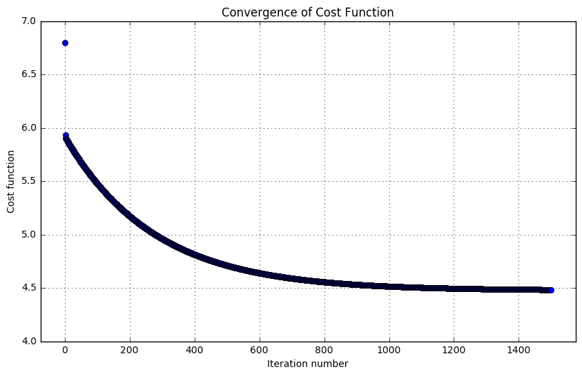

```python
#Actually run gradient descent to get the best-fit theta values
initial_theta = np.zeros((X.shape[1],1))
theta, thetahistory, jvec = GradientDescent(X,initial_theta)

#Plot the convergence of the cost function
def plotConvergence(jvec):
    plt.figure(figsize=(10,6))
    plt.plot(range(len(jvec)),jvec,'bo')
    plt.grid(True)
    plt.title("Convergence of Cost Function")
    plt.xlabel("Iteration number")
    plt.ylabel("Cost function")
    plt.xlim([-0.05*iterations,1.05*iterations])
    #plt.ylim([4,8])


plotConvergence(jvec)
plt.ylim([4,7])
```

### Plotting Regression Line

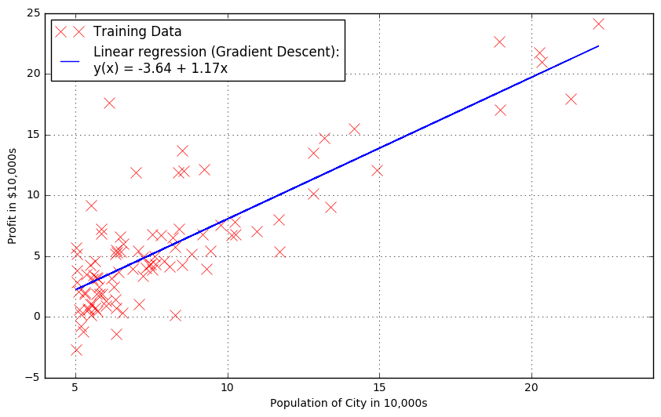

```python
#linear regression
def myfit(xval):
    return theta[0] + theta[1]*xval

#Plot linear regression line
plt.figure(figsize=(10,6))
plt.plot(X[:,1],y[:,0],'rx',markersize=10,label='Training Data')
plt.plot(X[:,1],myfit(X[:,1]),'b-',label = 'Linear regression (Gradient Descent):\ny(x) = %0.2f + %0.2fx'%(theta[0],theta[1]))
plt.xlim(4,24)
plt.xlabel('Population of City in 10,000s')
plt.ylabel('Profit in $10,000s')

plt.grid(True)
plt.ylabel('Profit in $10,000s')
plt.xlabel('Population of City in 10,000s')
plt.legend(loc='best')
```

```python
# Predict profit for a city with population of 35,000 and 70,000
print(myfit(35000))
print(myfit(70000))
```

```
[ 40840.9844723]
[ 81685.60500807]
```

## 2.4 Visualizing J(θ)

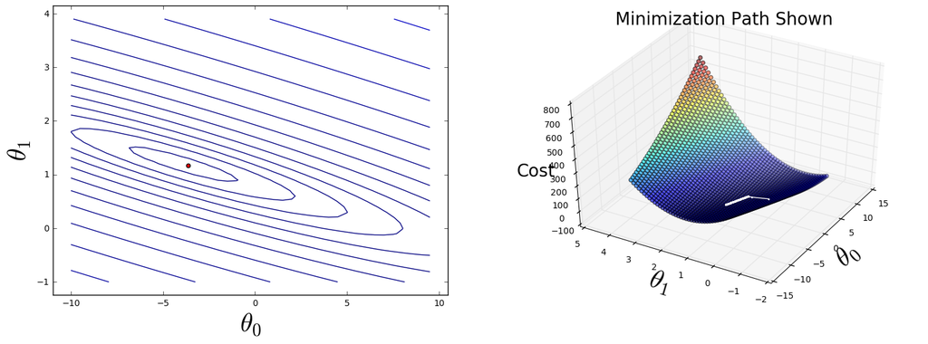

```python
#Import necessary matplotlib tools for 3d plots
from mpl_toolkits.mplot3d import axes3d, Axes3D
from matplotlib import cm
import itertools

fig = plt.figure(figsize=(18,6))
ax1 = fig.add_subplot(121)
ax2 = fig.add_subplot(122, projection='3d')

xvals = np.arange(-10,10,.5)
yvals = np.arange(-1,4,.1)

xx, yy = np.meshgrid(xvals, yvals, indexing='xy')
Z = np.zeros((yvals.size, xvals.size))
for (i,j),v in np.ndenumerate(Z):
    Z[i,j] = computeCost(np.array([[xx[i,j]], [yy[i,j]]]),X,y)

myxs, myys, myzs = [], [], []
for xval in xvals:
    for yval in yvals:
        myxs.append(xval)
        myys.append(yval)
        myzs.append(computeCost(np.array([[xval], [yval]]),X,y))

cont = ax1.contour(xx, yy, Z, np.logspace(-1, 4, 30), cmap=plt.cm.jet)
ax1.scatter(theta[0],theta[1], c='r')
ax1.set_xlabel(r'$\theta_0$',fontsize=30)
ax1.set_ylabel(r'$\theta_1$',fontsize=30)

scat = ax2.scatter(myxs,myys,myzs,c=np.abs(myzs),cmap=plt.get_cmap('jet')) #YlOrRd
#scat = ax2.plot_surface(myxs, myys, myzs, rstride=1, cstride=1, alpha=0.6, cmap=plt.cm.jet)

ax2.set_xlabel(r'$\theta_0$',fontsize=30)
ax2.set_ylabel(r'$\theta_1$',fontsize=30)
ax2.set_zlabel(r'Cost',fontsize=20)
ax2.set_title('Minimization Path Shown',fontsize=20)
ax2.plot([x[0] for x in thetahistory],[x[1] for x in thetahistory],jvec,'wo-', markeredgecolor='none', markersize=2)
#change elevation and azimuth
ax2.view_init(elev=40, azim=210)
plt.show()

#to do: make interactive, rotate plot
```

# 3. Linear Regression with Multiple Variables

In this part, we will implement linear regression with multiple variables to predict the prices of houses. Suppose we are selling your house and we want to know what a good market price would be. One way to do this is to first collect information on recent houses sold and make a model of housing prices.

The file `ex1data2.txt` contains a training set of housing prices in Portland, Oregon. The first column is the size of the house (in square feet), the second column is the number of bedrooms, and the third column is the price of the house.

```python
datafile = 'data/ex1data2.txt'

#Read into the data file
cols = np.loadtxt(datafile,delimiter=',',usecols=(0,1,2),unpack=True) #Read in comma separated data
```

```python
#show first 5 elements
cols[0,:5] #1st col: size of the house
```

```
array([ 2104.,  1600.,  2400.,  1416.,  3000.])
```

```python
cols[1,:5] #2nd col: number of bedrooms
```

```
array([ 3.,  3.,  3.,  2.,  4.])
```

```python
cols[2,:5] #3rd col: price of the house
```

```
array([ 399900.,  329900.,  369000.,  232000.,  539900.])
```

```python
#Form the usual "X" matrix and "y" vector
X = np.transpose(np.array(cols[:-1]))
y = np.transpose(np.array(cols[-1:]))
m = y.size # number of training examples

X[:5]
```

```
array([[  2.10400000e+03,   3.00000000e+00],
       [  1.60000000e+03,   3.00000000e+00],
       [  2.40000000e+03,   3.00000000e+00],
       [  1.41600000e+03,   2.00000000e+00],
       [  3.00000000e+03,   4.00000000e+00]])
```

```python
#Insert the usual column of 1's into the "X" matrix
X = np.insert(X,0,1,axis=1)
X[:5]
```

```
array([[  1.00000000e+00,   2.10400000e+03,   3.00000000e+00],
       [  1.00000000e+00,   1.60000000e+03,   3.00000000e+00],
       [  1.00000000e+00,   2.40000000e+03,   3.00000000e+00],
       [  1.00000000e+00,   1.41600000e+03,   2.00000000e+00],
       [  1.00000000e+00,   3.00000000e+03,   4.00000000e+00]])
```

```python
y[:5] #price of the house
```

```
array([[ 399900.],
       [ 329900.],
       [ 369000.],
       [ 232000.],
       [ 539900.]])
```

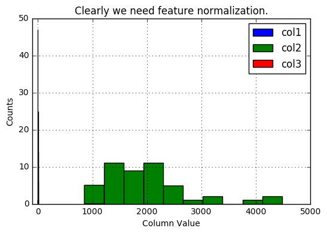

```python
#Quickly visualize data
plt.grid(True)
plt.xlim([-100,5000])
plt.hist(X[:,0],label = 'col1')
plt.hist(X[:,1],label = 'col2')
plt.hist(X[:,2],label = 'col3')
plt.title('Clearly we need feature normalization.')
plt.xlabel('Column Value')
plt.ylabel('Counts')
plt.legend()
```

## 3.1 Feature normalization

By looking at the values, note that house sizes are about 1000 times the number of bedrooms. When features differ by orders of magnitude, first performing feature scaling can make gradient descent converge much more quickly.

Normalization requires us to:

- Subtract the mean value of each feature from the dataset.
- Scale (divide) the feature values by their respective "standard deviations."

The standard deviation is a way of measuring how much variation there is in the range of values of a particular feature (most data points will lie within $\pm$2 standard deviations of the mean); this is an alternative to taking the range of values (max-min). We can use `np.std` to get the standard deviation.

```python
#Feature normalizing the columns (subtract mean, divide by standard deviation)
#Store the mean and std for later use
stored_feature_means, stored_feature_stds = [], []

#Note don't modify the original X matrix, use a copy
Xnorm = X.copy()
for icol in range(Xnorm.shape[1]):
    stored_feature_means.append(np.mean(Xnorm[:,icol]))
    stored_feature_stds.append(np.std(Xnorm[:,icol]))
    #Skip the first column
    if not icol: continue
    #Faster to not recompute the mean and std again, just used stored values
    Xnorm[:,icol] = (Xnorm[:,icol] - stored_feature_means[-1])/stored_feature_stds[-1]
```

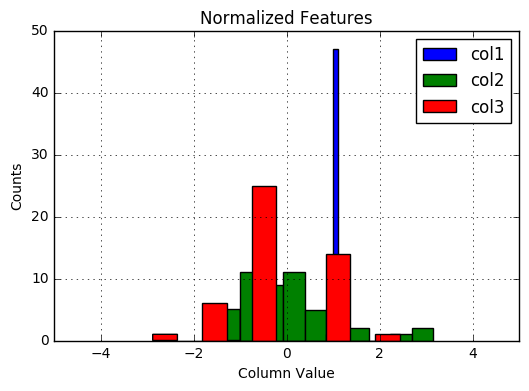

```python
#Quickly visualize the feature-normalized data
plt.grid(True)
plt.xlim([-5,5])
plt.hist(Xnorm[:,0],label = 'col1')
plt.hist(Xnorm[:,1],label = 'col2')
plt.hist(Xnorm[:,2],label = 'col3')
plt.title('Normalized Features')
plt.xlabel('Column Value')
plt.ylabel('Counts')
plt.legend()
```

## 3.2. Gradient Descent

Previously, we implemented gradient descent on a univariate regression problem. The only difference now is that there is one more feature in the matrix `X`. The hypothesis function and the batch gradient descent update rule remain unchanged.

The normalized-feature vector `Xnorm` and parameters `initial_theta` are inputted to `GradientDescent()` to implement the cost function and gradient descent for linear regression with multiple variables.

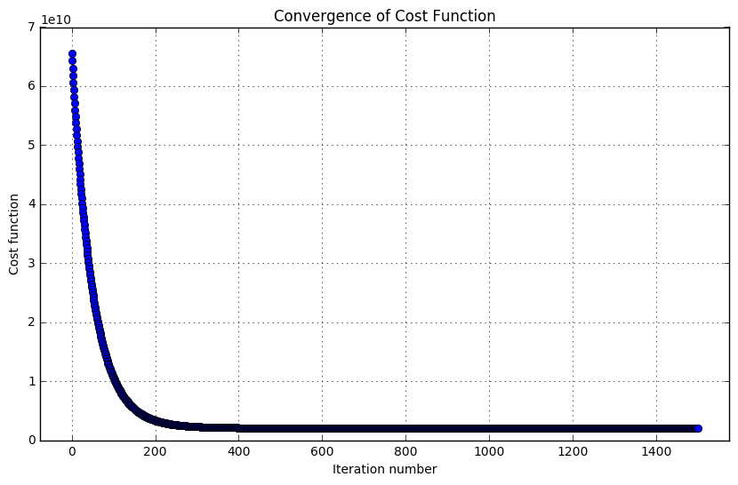

```python
#Run gradient descent with multiple variables, initial theta still set to zeros
initial_theta = np.zeros((Xnorm.shape[1],1))
theta2, thetahistory2, jvec2 = GradientDescent(Xnorm,initial_theta)

#Plot convergence of cost function:
plotConvergence(jvec2)
```

```python
def myfit(xval):
    return theta2[0] + theta2[1]*xval
```

Prediction of price of house with 1650 square feet and 3 bedrooms

```python
ytest = np.array([1650.,3.])

#To "undo" feature normalization, we "undo" 1650 and 3, then plug it into our hypothesis
ytestscaled = [(ytest[x]-stored_feature_means[x+1])/stored_feature_stds[x+1] for x in range(len(ytest))]
ytestscaled.insert(0,1)
```

```python
#print "Final result theta parameters: \n",theta
print("What is price of house with 1650 square feet and 3 bedrooms?")
print("$%0.2f" % float(h(theta2,ytestscaled)))
```

```
What is price of house with 1650 square feet and 3 bedrooms?
$293098.15
```

## 3.3 Normal Equations

The closed-form solution to linear regression is $$ \theta = (X^TX)^{-1}X^Ty $$

Using this formula does not require any feature scaling, and we will get an exact solution in one calculation: there is no "loop until convergence" like in gradient descent.

```python
from numpy.linalg import inv
#Implementation of normal equation to find analytic solution to linear regression
def normEqtn(X,y):
    #restheta = np.zeros((X.shape[1],1))
    return np.dot(np.dot(inv(np.dot(X.T,X)),X.T),y)
```

```python
print("Normal equation prediction for price of house with 1650 square feet and 3 bedrooms:")
print("$%0.2f" % float(h(normEqtn(X,y),[1,1650.,3])))
```

```
Normal equation prediction for price of house with 1650 square feet and 3 bedrooms:
$293081.46
```

We find that gives about the same predicted price as the value we obtained using the model fit with gradient descent.

In our calculation, their difference is

```python
float(h(theta2,ytestscaled)) - float(h(normEqtn(X,y),[1,1650.,3]))
```

```
16.68491264153272
```

# Appendix

## Comparison with scikit-learn + pandas

Using [sklearn.linear_model.LinearRegression](http://scikit-learn.org/stable/modules/generated/sklearn.linear_model.LinearRegression.html) is a quick way of doing regression. See another examples [here](http://scikit-learn.org/stable/auto_examples/plot_cv_predict.html#sphx-glr-auto-examples-plot-cv-predict-py) and [here](http://scikit-learn.org/stable/modules/linear_model.html).

```python
import pandas as pd

#load data as pandas dataframe
df = pd.read_csv('data/ex1data1.txt', delimiter=',', names=['population','profit'], dtype='float64')
```

```python
df.head()
```

|  | population | profit |
| --- | --- | --- |
| 0 | 6.1101 | 17.5920 |
| 1 | 5.5277 | 9.1302 |
| 2 | 8.5186 | 13.6620 |
| 3 | 7.0032 | 11.8540 |
| 4 | 5.8598 | 6.8233 |

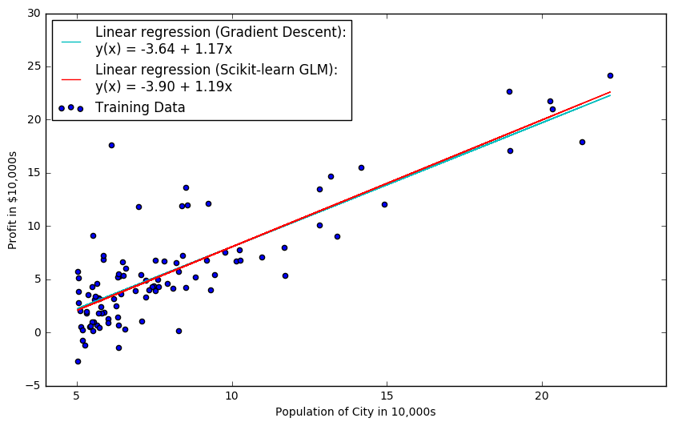

```python
import pandas as pd

#linear regression
def myfit(xval):
    return theta[0] + theta[1]*xval

x=df.population.values
X=x.reshape(-1,1)
y=df.profit.values

#Plot linear regression line
fig, ax = plt.subplots(nrows=1,ncols=1,figsize=(10,6))
ax1 = df.plot('population', 'profit', kind='scatter',label='Training Data', ax=ax) #markersize=10,
ax2 = ax.plot(x, myfit(x), color='c',label = 'Linear regression (Gradient Descent):\ny(x) = %0.2f + %0.2fx'%(theta[0],theta[1]))

### Compare with Scikit-learn Linear regression
from sklearn.linear_model import LinearRegression
regr = LinearRegression()


#regr.fit(X[:,1].reshape(-1,1), y.ravel())
regr.fit(X, y)
predicted = regr.intercept_+regr.coef_*x
ax.plot(x, predicted, 'r-', label='Linear regression (Scikit-learn GLM):\ny(x) = %0.2f + %0.2fx'%(regr.intercept_,regr.coef_))

#plt.grid(True)
ax.set_xlim(4,24)
ax.set_ylabel('Profit in $10,000s')
ax.set_xlabel('Population of City in 10,000s')
plt.legend(loc='best')
```

```python
# Predict profit for a city with population of 35,000 and 70,000 using sklearn.predict
vals = [35000, 70000]

for i in vals:
    print(regr.predict(i))
```

```
[ 41752.28176576]
[ 83508.45931239]
```

```python
# coefficient of determination R**2
R2=regr.score(X,y)
print('R^2={}'.format(R2))
```

```
R^2=0.702031553784
```

R^2 suggests that the regression line does not approximate the real data points quite well. Let's try sklearn's [`cross_val_predict`](http://scikit-learn.org/stable/auto_examples/plot_cv_predict.html#sphx-glr-auto-examples-plot-cv-predict-py) to visualize prediction errors.

As shown below, the prediction of `cross_val_predict` does not strictly follow a straight line i.e. with small offsets.

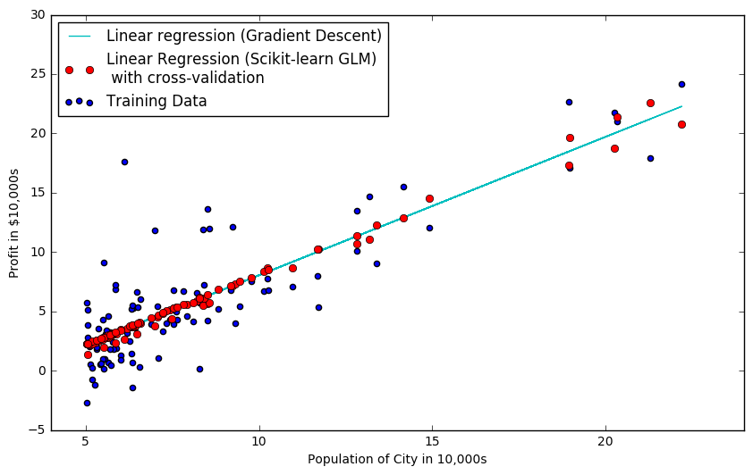

```python
import pandas as pd

#linear regression
def myfit(xval):
    return theta[0] + theta[1]*xval

x=df.population.values
X=x.reshape(-1,1)
y=df.profit.values

#Plot linear regression line
fig, ax = plt.subplots(nrows=1,ncols=1,figsize=(10,6))
ax1 = df.plot('population', 'profit', kind='scatter',label='Training Data', ax=ax) #markersize=10,
ax2 = ax.plot(x, myfit(x), 'c-',label = 'Linear regression (Gradient Descent)')

### Compare with Scikit-learn Linear regression
from sklearn.linear_model import LinearRegression
from sklearn.model_selection import cross_val_predict
regr = LinearRegression()

regr.fit(X, y)
predicted_crossval = cross_val_predict(regr, X, y, cv=10)
ax.plot(x, predicted_crossval, 'ro', label='Linear Regression (Scikit-learn GLM)\n with cross-validation')
#ax.plot([x.min(), x.max()], [predicted_crossval.min(), predicted_crossval.max()], 'r-',label='Linear Regression (Scikit-learn GLM)\n with cross-validation')

#:\ny(x) = %0.2f + %0.2fx'%(regr.intercept_,regr.coef_)

#plt.grid(True)
ax.set_xlim(4,24)
ax.set_ylabel('Profit in $10,000s')
ax.set_xlabel('Population of City in 10,000s')
plt.legend(loc='best')
```

Let's see if the [quality of our prediction](http://scikit-learn.org/stable/modules/model_evaluation.html) has improved with the use of cross-validation.

```python
from sklearn import metrics

# coefficient of determination R**2
R2=regr.score(X,y) #without cross-validation
#R2 = metrics.r2_score(y, predicted)
R2_crossval = metrics.r2_score(y, predicted_crossval)  #with cross-validation

print('R^2={0}\nR^2 (with cross-validation)={1} '.format(R2, R2_crossval))
```

```
R^2=0.702031553784
R^2 (with cross-validation)=0.649997941106
```

## Comparison with seaborn + pandas

Using [seaborn.regplot](http://seaborn.pydata.org/generated/seaborn.regplot.html) is a quick way of visualizing regression plots.

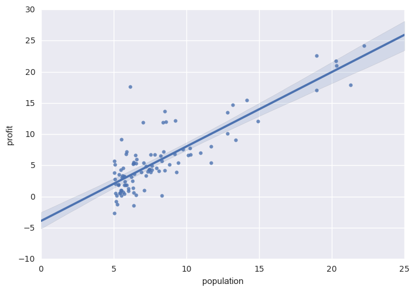

```python
### Compare with seaborn + Linear regression
import seaborn as sb

sb.regplot(x="population", y="profit", data=df) #order=1, robust=True, ci=None, x_estimator=np.mean
```

## Generating mock data

To reproduce the original data in the first part of this exercise, we need the mean and [covariance](https://en.wikipedia.org/wiki/Covariance) of the model of the original data. We suppose that the data is described by a multivariate normal distribution.

```python
#import statmodels as sm
import pandas.stats as stats
```

```python
df.describe()
```

|  | population | profit |
| --- | --- | --- |
| count | 97.000000 | 97.000000 |
| mean | 8.159800 | 5.839135 |
| std | 3.869884 | 5.510262 |
| min | 5.026900 | -2.680700 |
| 25% | 5.707700 | 1.986900 |
| 50% | 6.589400 | 4.562300 |
| 75% | 8.578100 | 7.046700 |
| max | 22.203000 | 24.147000 |

```python
import numpy as np

#get the mean
xmean = np.mean(df.population.values)
ymean = np.mean(df.profit.values)

print(xmean,ymean)
```

```
(8.1597999999999988, 5.8391350515463927)
```

```python
#get the covariance
df.cov()
```

|  | population | profit |
| --- | --- | --- |
| population | 14.975999 | 17.86687 |
| profit | 17.866870 | 30.36299 |

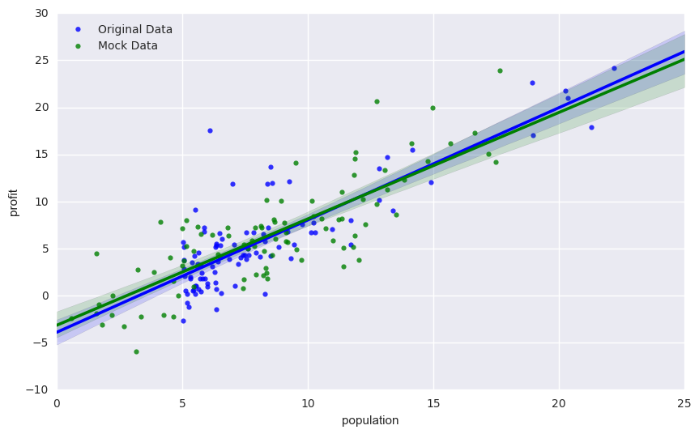

```python
import numpy as np
np.random.seed(8) #for reproducibility

mean = [xmean, ymean]
cov = [df.cov().values[0], df.cov().values[1]]
num_datapoints=len(df)#97
x, y = np.random.multivariate_normal(mean, cov, num_datapoints).T

fig, ax = plt.subplots(nrows=1,ncols=1,figsize=(10,6))
ax3 = sb.regplot(x=df.population, y=df.profit, color="b", label='Original Data', ax=ax) #markersize=10,
ax4 = sb.regplot(x=x, y=y, color="g", label='Mock Data', ax=ax)
plt.legend(loc=2) #'best'
```

The model can be better represented with a distribution which is slightly skewed and has a long tail as shown below.

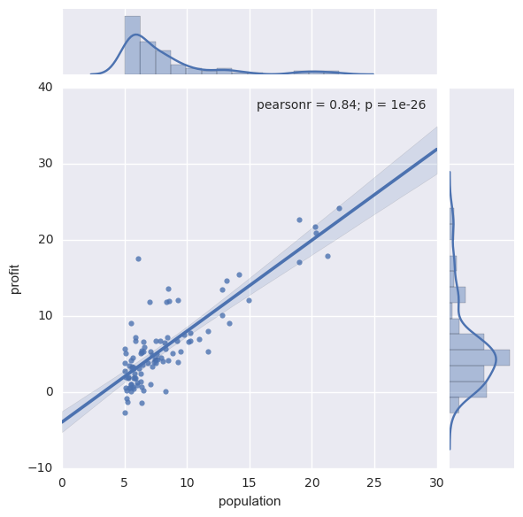

```python
import seaborn as sb

sb.jointplot(x="population", y="profit", data=df, kind="reg")
```